# Cell state dependent drug response analysis

Author

Evert Bosdriesz

Published

October 21, 2024

## Background

Single cells were clustered into 9 cell state clusters based on the expression of proteins that were not differentially expressed between drug treatments (c.f. cell-state-clustering folder). These clusters appear to have some relation to signaling-state. Here, we investigate if some (phospho-)protein responses are cluster dependent, as this would suggest a cell-state dependent drug response that is potentially relevant to drug resistance. To this end, we regress the expression of each antibody in each cell to the drug-treatment and cell-state cluster, and include an interaction term, i.e. we fit the following model for each antibody.

$$expression_{i,x} ~ \beta_0 + \beta_{t}*treatment + \beta_{c}*cellstate + \beta_{i}*treatment * cellstate$$

Antibodies for which there are significant interaction term show signs cell-state dependent drug response.

We will use the z-score normalized data as input because this allows for visualization of all antibodies on the same scale. Note that this does not affect the p-values for significance of the interaction term (which is shown at the end of the notebook).

Our input data looks as follows:

```r
dat_tmm <- read_tsv(here("data", "processed", "scIDseq-vanEijl-tmm.tsv")) %>%
  select(sample_id, treatment, ab_name, ab_type, ab_count_tmm) %>%
  filter(treatment != "No_EGF") %>%
  mutate(treatment = factor(treatment, levels = c("EGF", "ip70S6K_EGF", "iRSK_EGF")))


dat_zscore <- read_csv(
  here("data", "processed" ,"TMM_normalised_z_transformed_concencus_clusters.csv")
  ) %>%
  select(-...1, -plate_number, -treatment) %>%
  mutate(cluster = as_factor(cluster)) %>%
  pivot_longer(!c(cluster, sample_id), names_to = "ab_name", values_to = "zscore")


dat <- left_join(dat_tmm, dat_zscore)

rm(dat_tmm, dat_zscore)
head(dat)
```

```
# A tibble: 6 × 7
  sample_id    treatment   ab_name ab_type ab_count_tmm cluster zscore
  <chr>        <fct>       <chr>   <chr>          <dbl> <fct>    <dbl>
1 plate_10_171 ip70S6K_EGF ITGB1   total          0.407 1        0.496
2 plate_2_171  ip70S6K_EGF ITGB1   total          0.342 2       -0.225
3 plate_3_171  iRSK_EGF    ITGB1   total          0.274 2       -0.974
4 plate_6_171  EGF         ITGB1   total          0.149 3       -2.35
5 plate_8_171  ip70S6K_EGF ITGB1   total          0.536 4        1.91
6 plate_10_169 EGF         ITGB1   total          0.331 2       -0.346
```

We can now visualize the expression of an antibody in an cell-state dependent manner:

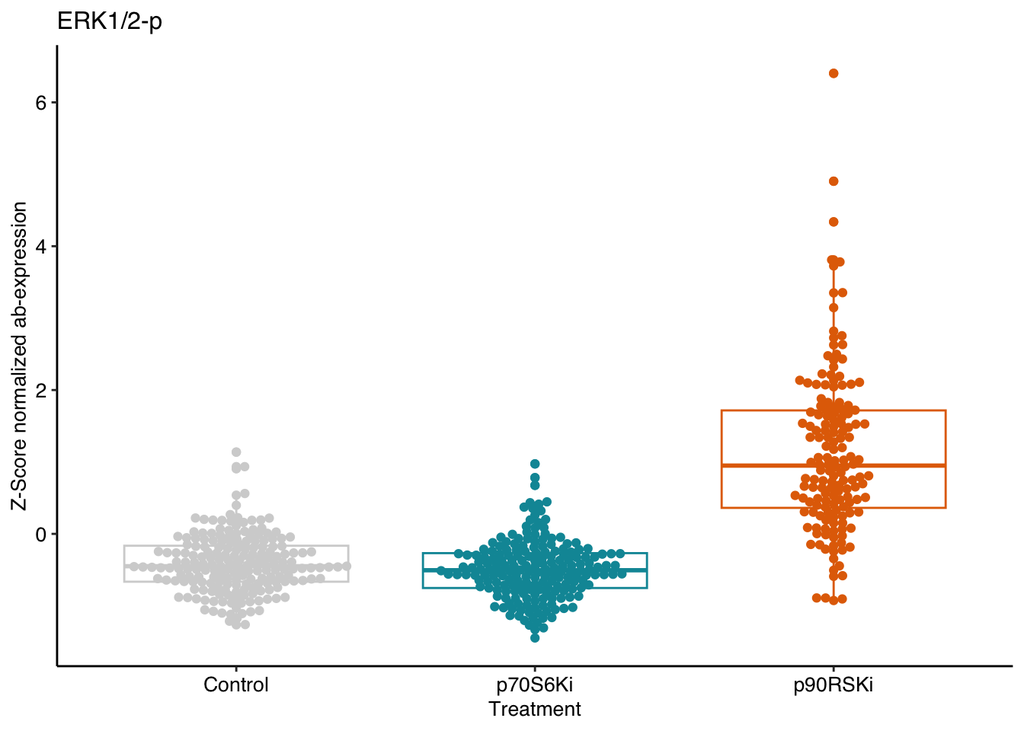

```r
plot_ab <- function(ab) {
  ggplot(
    filter(dat, ab_name == ab),
    aes(x = cluster, y = zscore, fill = treatment)
  ) +
    geom_boxplot() +
    #ggbeeswarm::geom_beeswarm() +
    #expand_limits(y = 0) +
    my_theme +
    scale_fill_manual(values = col_lst) +
    labs(title = ab, x = "Cell state cluster", y = "z-score normalized ab-expression")
}

plot_ab_nocluster <- function(ab) {
  ggplot(
    filter(dat, ab_name == ab),
    aes(x = treatment, y = zscore, color = treatment)
  ) +
    geom_boxplot() +
    ggbeeswarm::geom_beeswarm() +
    #expand_limits(y = 0) +
    presentation_theme +
    scale_color_manual(values = col_lst) +
    scale_x_discrete(labels = tx_labs) +
    labs(title = ab, x = "Treatment", y = "Z-Score normalized ab-expression",
         ) +
    theme(legend.position = "none")
  }

plot_ab_nocluster("ERK1_2_P") +
  labs(title = "ERK1/2-p") +
  theme(legend.position = "none") +
  presentation_theme
```

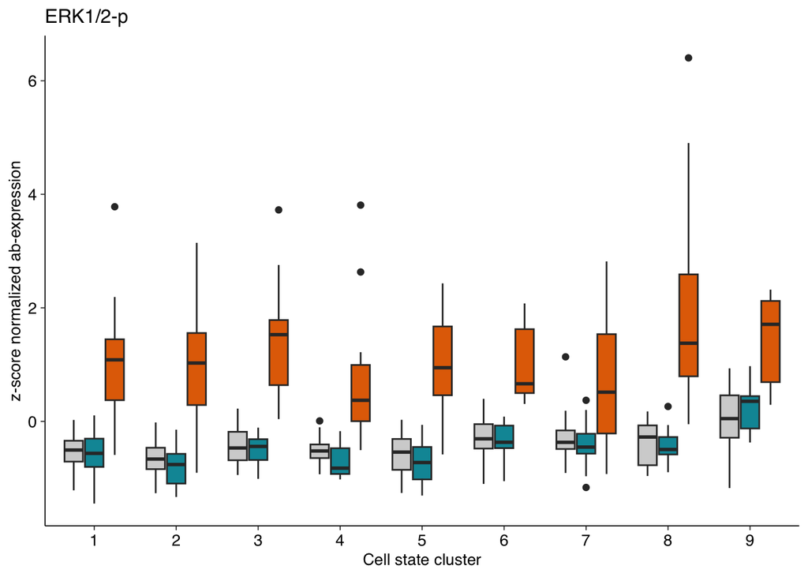

```r
plot_ab("ERK1_2_P") +
  labs(title = "ERK1/2-p") +
  theme(legend.position = "none") +
  presentation_theme
```

## Analysis

### Data exploration

Let’s first briefly explore the clusters. How many cells are there in each cluster, and which treatment did they receive?

```r
dat %>%
  ungroup() %>%
  select(sample_id, treatment, cluster) %>%
  group_by(treatment, cluster) %>%
  distinct() %>%
  summarise(N = n()) %>%
  pivot_wider(names_from = treatment, values_from = N) %>%
  mutate(total = EGF + ip70S6K_EGF + iRSK_EGF)
```

```
# A tibble: 9 × 5
  cluster   EGF ip70S6K_EGF iRSK_EGF total
  <fct>   <int>       <int>    <int> <int>
1 1          20          22       12    54
2 2          30          24       36    90
3 3          26          20       17    63
4 4          14          18       13    45
5 5          14          22       26    62
6 6          34          17        7    58
7 7          22          45       17    84
8 8          22          13       22    57
9 9          14          13        6    33
```

Or visually.

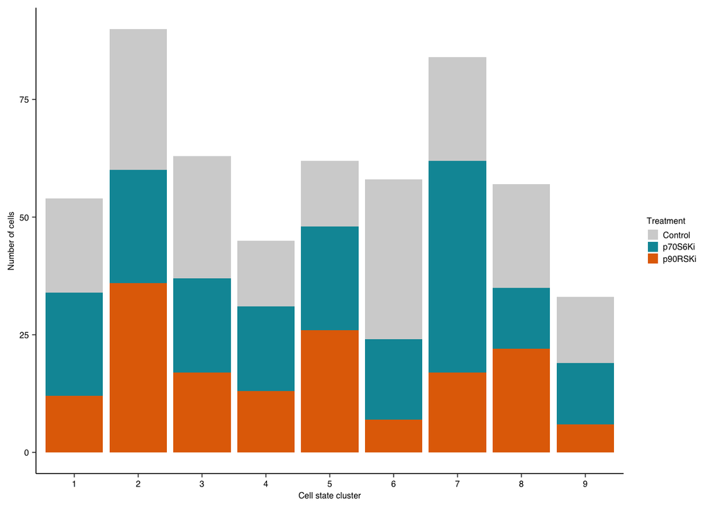

```r
dat %>%
  select(sample_id, treatment, cluster) %>%
  distinct() %>%
  ggplot(aes(x = cluster, fill = treatment)) +
  geom_bar() +
  scale_fill_manual(values = col_lst, labels = tx_labs, name = "Treatment") +
  labs(x = "Cell state cluster", y = "Number of cells") +
  theme(legend.key.size = unit(0.3, 'cm')) +
  my_theme
```

```r
# ggsave(
#   here("figures/manuscript/Supplemental figures/tx-cellstate-distribution.pdf"),
#   width = 3, height = 2)
```

We expect the treatments to be balanced over the clusters, as the duration of the treatment is too short to affect the cell state.

### Model fitting

#### Two-way Anova

We’ll first perform a two-way ANOVA as this is the simplest to interpret. This will give us significance levels per antibody, but not for individual interactions terms. The following antibodies have a significant interaction term (which means that the zscores can be significantly better described by a model with an interaction term compared to one without.)

```r
ab_name_lst <- as.list(unique(dat$ab_name))
names(ab_name_lst) <- ab_name_lst

model_anova <- purrr::map(
  ab_name_lst,
  function(x){tidy(aov(zscore ~ treatment * cluster, data = filter(dat, ab_name == x)))}
  ) %>%
  bind_rows(.id = "ab_name")

signif_interactions_anova <-
  model_anova |>
  dplyr::filter(term == "treatment:cluster") |>
  dplyr::mutate(fdr = p.adjust(p.value, method = "BH")) |>
  dplyr::arrange(fdr) |>
  dplyr::filter(fdr < 0.05)

signif_interactions_anova |>
  select(ab_name, p.value, fdr)
```

```
# A tibble: 11 × 3
   ab_name         p.value      fdr
   <chr>             <dbl>    <dbl>
 1 H3_P           1.10e-11 7.56e-10
 2 CYCLIN_B1      2.61e- 5 8.99e- 4
 3 CYCLIN_E       2.46e- 4 5.65e- 3
 4 H2A_P          1.81e- 3 1.56e- 2
 5 FAK            1.75e- 3 1.56e- 2
 6 GAPDH          1.76e- 3 1.56e- 2
 7 RIBOSOMAL_S6_P 1.09e- 3 1.56e- 2
 8 SRC_P          1.27e- 3 1.56e- 2
 9 ERK1_2         2.17e- 3 1.67e- 2
10 AKT2           3.39e- 3 2.34e- 2
11 STAT5_P        4.31e- 3 2.71e- 2
```

```r
write_tsv(signif_interactions_anova, here("results",  "treatment_cellstate_interactions_anova.tsv"))
```

Phospho H3 is the most significant.

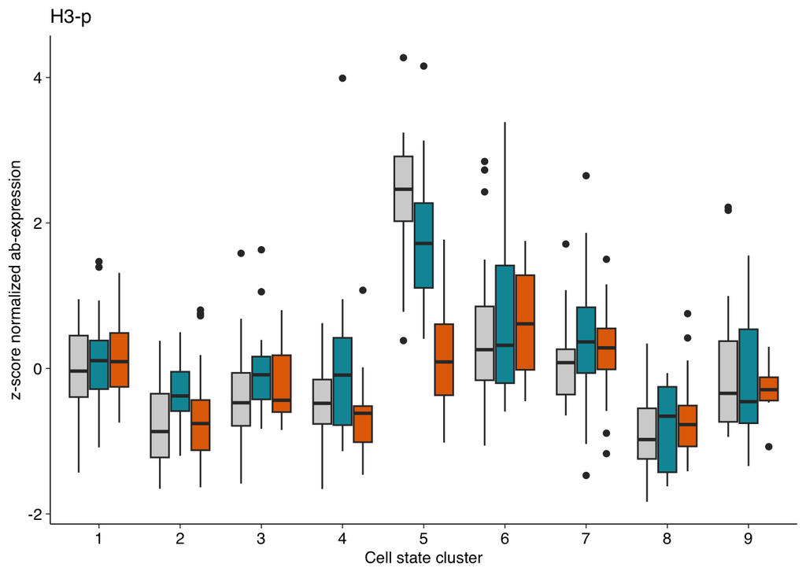

```r
plot_ab("H3_P") +
  labs(title = "H3-p") +
  theme(legend.position = "none") +
  presentation_theme
```

#### Regression with interaction term

The downside of an ANOVA model, is that it does not indicate for which cell-state-treatment combination the interactions is (but just that a model with an interaction term fits the data significantly better). Therefor, let’s fit a regular linear model with interaction term. In addition, we obtain the “fit” for each treatment-cluster combination and the corresponding the 95% confidence interval. For comparison, we’ll also fit a model without an interaction term.

As reference levels, we select EGF only treatment and cluster 1. Later we’ll explore the effect of using different clusters as reference.

```r
get_fit <- function(ab, df, formula){
  lm(formula, filter(df, ab_name == ab))
}


formula_simple <- zscore ~  0 + cluster + treatment
formula_interaction <- zscore ~ 0 + cluster * treatment


fit_lst_simple <- purrr::map(ab_name_lst, get_fit, dat, formula_simple)
fit_lst_interaction <- purrr::map(ab_name_lst, get_fit, dat, formula_interaction)

model_simple <-
  purrr::map(fit_lst_simple, tidy) %>%
  bind_rows(.id = "ab_name") %>%
  mutate(fdr = p.adjust(p.value, method = "BH")) %>%
  mutate(term_type = case_when(
    str_detect(term, ":") ~ "interaction",
    str_detect(term, "(Intercept)") ~ "intercept",
    str_detect(term, "treatment") ~ "treatment",
    TRUE ~ "cluster"
  ))

model_interaction <-
  purrr::map(fit_lst_interaction, tidy) %>%
  bind_rows(.id = "ab_name") %>%
  mutate(fdr = p.adjust(p.value, method = "BH")) %>%
  mutate(term_type = case_when(
    str_detect(term, ":") ~ "interaction",
    str_detect(term, "(Intercept)") ~ "intercept",
    str_detect(term, "treatment") ~ "treatment",
    TRUE ~ "cluster"
  ))

write_tsv(model_simple, here("results", "model-exp-lm"))
write_tsv(model_interaction, here("results", "model-exp-interaction.tsv"))
```

To get p-values for each individual interaction term, we can simply inspect the coefficients of the interaction term in the linear model.

Note that the final model is mathematically equivalent to the two-way ANOVA in that model predictions/fits are identical. Let’s consider the significant interactions. A table with all significant interactions is written to results/scIDseq/treatment_cellstate_interactions.tsv, and a table with all coefficients of the linear and interaction model to results/scIDseq/model-exp-lm.tsv and results/scIDseq/model-exp-interaction.tsv, respectively.

```r
signif_interactions <-
  model_interaction %>%
  filter(term_type == "interaction" & p.value < 0.05) %>%
  arrange(fdr) %>%
  separate(term, into = c("cluster", "treatment"), sep = ":", remove = FALSE) %>%
  mutate(
    treatment = stringr::str_replace(treatment, "treatment", ""),
    cluster = stringr::str_replace(cluster, "cluster", "")
  )

write_tsv(signif_interactions, here("results", "treatment_cellstate_interactions.tsv"))
```

```r
head(signif_interactions, n = 10)
```

```
# A tibble: 10 × 10
   ab_name term  cluster treatment estimate std.error statistic  p.value     fdr
   <chr>   <chr> <chr>   <chr>        <dbl>     <dbl>     <dbl>    <dbl>   <dbl>
 1 H3_P    clus… 5       iRSK_EGF     -2.31     0.366     -6.30 6.43e-10 3.24e-8
 2 CYCLIN… clus… 9       ip70S6K_…     2.11     0.391      5.40 9.97e- 8 3.10e-6
 3 JAK1_P  clus… 9       ip70S6K_…     1.65     0.386      4.29 2.12e- 5 3.21e-4
 4 NFKB_P… clus… 9       ip70S6K_…     1.39     0.355      3.92 1.01e- 4 1.28e-3
 5 AKT2    clus… 9       ip70S6K_…     1.49     0.386      3.85 1.33e- 4 1.63e-3
 6 STAT5_P clus… 9       ip70S6K_…     1.43     0.375      3.81 1.53e- 4 1.85e-3
 7 SRC_P   clus… 9       ip70S6K_…     1.42     0.389      3.64 3.02e- 4 3.37e-3
 8 ERK1_2  clus… 8       iRSK_EGF     -1.22     0.340     -3.57 3.83e- 4 4.15e-3
 9 SMAD1_… clus… 9       ip70S6K_…     1.22     0.362      3.37 7.94e- 4 7.67e-3
10 SRC_P   clus… 6       ip70S6K_…     1.13     0.338      3.34 8.90e- 4 8.33e-3
# ℹ 1 more variable: term_type <chr>
```

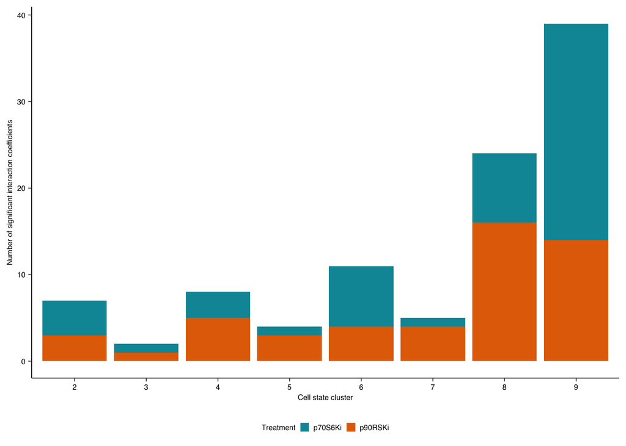

```r
ggplot(signif_interactions, aes(x=cluster, fill=treatment)) +
  geom_bar() +
  scale_fill_manual(values = col_lst, labels = tx_labs, name = "Treatment") +
  labs(x = "Cell state cluster", y = "Number of significant interaction coefficients") +
  theme(legend.key.size = unit(0.3, 'cm')) +
  my_theme +
  theme(legend.position = "bottom")
```

```r
ggsave(
  here("figures/manuscript/Supplemental figures/significant-interaction-cellstate-distribution.pdf"),
  width = 2, height = 2)
```

Cluster 9 seems to show the most. Indeed, most are between p70S6K inhibition and cluster 9.

```r
group_by(signif_interactions, cluster, treatment) %>%
  summarise(N = n()) %>%
  arrange(desc(N))
```

```
# A tibble: 16 × 3
# Groups:   cluster [8]
   cluster treatment       N
   <chr>   <chr>       <int>
 1 9       ip70S6K_EGF    25
 2 8       iRSK_EGF       16
 3 9       iRSK_EGF       14
 4 8       ip70S6K_EGF     8
 5 6       ip70S6K_EGF     7
 6 4       iRSK_EGF        5
 7 2       ip70S6K_EGF     4
 8 6       iRSK_EGF        4
 9 7       iRSK_EGF        4
10 2       iRSK_EGF        3
11 4       ip70S6K_EGF     3
12 5       iRSK_EGF        3
13 3       iRSK_EGF        1
14 3       ip70S6K_EGF     1
15 5       ip70S6K_EGF     1
16 7       ip70S6K_EGF     1
```

However, it should be noted that this is based on just 13 cells.

```r
model_interaction %>%
  filter(term_type == "treatment" & p.value < 0.05) %>%
  arrange(fdr)
```

```
# A tibble: 37 × 8
   ab_name      term     estimate std.error statistic  p.value     fdr term_type
   <chr>        <chr>       <dbl>     <dbl>     <dbl>    <dbl>   <dbl> <chr>
 1 ERK1_2_P     treatme…    1.61      0.242      6.65 7.46e-11 4.80e-9 treatment
 2 MAPK_APK2_P  treatme…    1.64      0.279      5.87 7.56e- 9 3.35e-7 treatment
 3 CMYC         treatme…   -1.51      0.274     -5.51 5.52e- 8 1.87e-6 treatment
 4 KALLIKREIN_6 treatme…    1.59      0.300      5.29 1.83e- 7 5.17e-6 treatment
 5 NFKB_P65_P   treatme…   -1.15      0.263     -4.37 1.52e- 5 2.42e-4 treatment
 6 CJUN_P       treatme…   -0.992     0.242     -4.11 4.63e- 5 6.54e-4 treatment
 7 SRC          treatme…   -1.21      0.302     -3.99 7.54e- 5 9.82e-4 treatment
 8 RSK1_P_T359  treatme…   -1.12      0.288     -3.87 1.22e- 4 1.51e-3 treatment
 9 H2A_P        treatme…   -1.15      0.299     -3.84 1.40e- 4 1.71e-3 treatment
10 SMAD1        treatme…   -1.16      0.309     -3.76 1.87e- 4 2.20e-3 treatment
# ℹ 27 more rows
```

#### Visualizations

```r
prediction_input <- distinct(select(dat, treatment, cluster)) %>%
  arrange(cluster, treatment)

get_predictions <- function(fit){
  bind_cols(
    prediction_input,
    as_tibble(predict(fit, prediction_input, interval = "confidence")))
}

predictions_interaction <-
  fit_lst_interaction %>%
  purrr::map(get_predictions) %>%
  bind_rows(.id = "ab_name")

predictions_simple <-
  fit_lst_simple %>%
  purrr::map(get_predictions) %>%
  bind_rows(.id = "ab_name")


predictions <- bind_rows(list(
  "interaction" = predictions_interaction,
  "simple" = predictions_simple),
  .id = "model_type"
  )
rm(predictions_interaction, predictions_simple, prediction_input)
```

Let’s visualize the expression patterns of some potentially interesting antibodies. In the plots below the model predictions for each treatment-cluster pair are indicated. For comparison, the dark gray points indicate the estimates using a model without an interaction term.

```r
plot_prediction <- function(ab){
  ggplot(filter(predictions, ab_name == ab & model_type == "interaction"),
    aes(y = fit, x = cluster, color = treatment, group=treatment)) +
    geom_point(
      data = filter(predictions, ab_name == ab & model_type == "simple"),
      color = "darkgray", size = 4, position = position_dodge(width = 0.5)) +
    geom_errorbar(
      data = filter(predictions, ab_name == ab & model_type == "simple"),
      aes(y = fit, ymin = lwr, ymax = upr, group = treatment),
      width = .5, position = position_dodge(width = 0.5), color = "darkgray"
    ) +
    geom_point(size = 4, position = position_dodge(width = 0.5)) +
    geom_errorbar(
      aes(y = fit, ymin = lwr, ymax = upr, color = treatment),
      width = .5, position = position_dodge(width = 0.5)
    ) +
  scale_color_manual(values = col_lst) +
  labs(title = ab, x = "Cell state cluster", y = "z-score (Model estimate)") +
  my_theme
}
```

### RSKi treatment and Cluster 5

Cluster 5 has high expression of both H3_P and CYCLIN_B1 (and to a lesser extend, H2A_P), which is affected by RSKi. For H3_P and H2A_P the upregulation in cluster 5 is repressed, whereas for CYCLIN_B1 it is extra pronounced

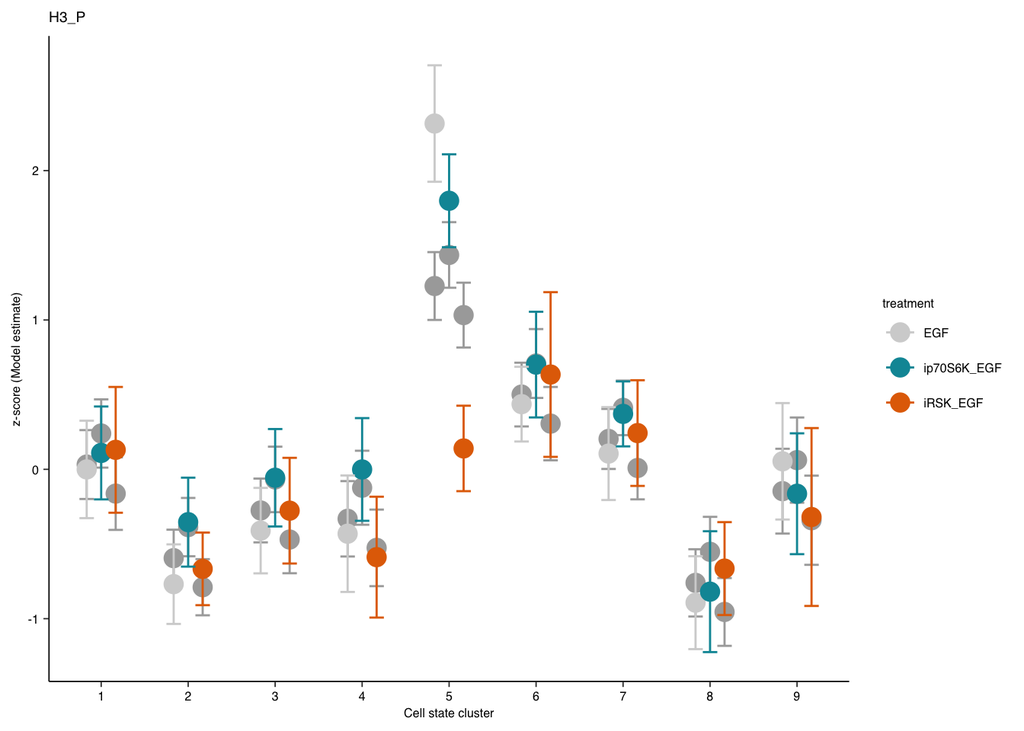

```r
plot_prediction("H3_P")
```

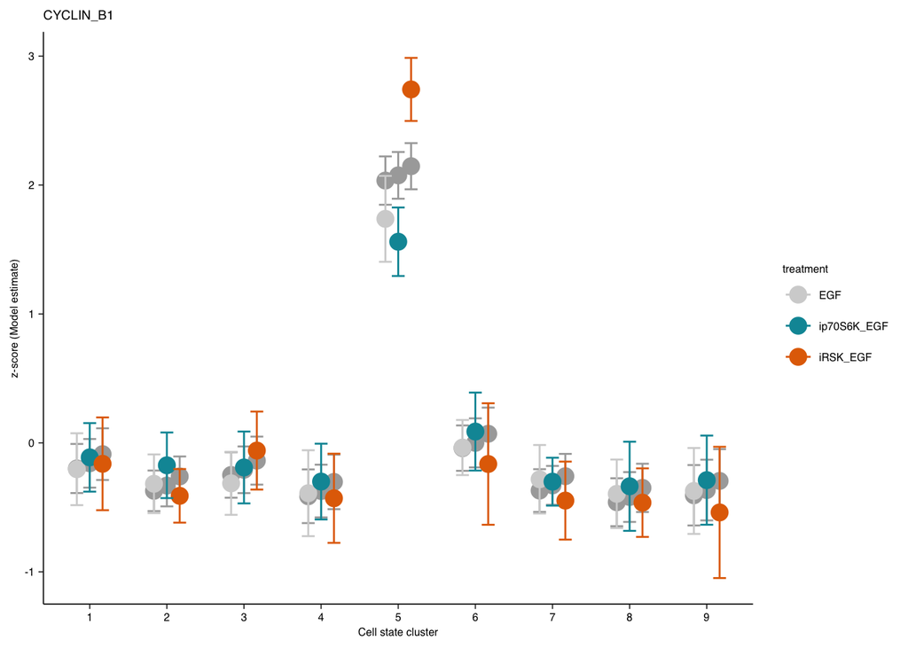

```r
plot_prediction("CYCLIN_B1")
```

### Overview of all terms

We’ll also create an overview of all interaction terms. Significance is indicated by a black circle around the dot.

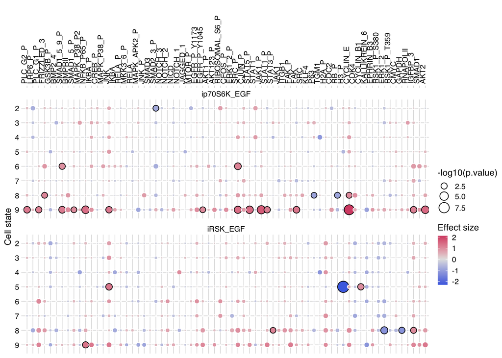

```r
ordered_ab_lst <- read_csv(
  here("data", "for-visualization", "ordered_antibody_list.csv"),
   col_names = FALSE)$X1

hc_treats <- filter(model_interaction, term_type == "interaction") %>%
  separate(term, into = c("cluster", "treatment"), sep = ":", remove = FALSE) %>%
  mutate(log10p = -log10(p.value)) %>%
  select(ab_name, term, log10p) %>%
  pivot_wider(names_from = term, values_from = log10p) %>%
  column_to_rownames("ab_name") %>%
  #as.matrix %>%
  dist() %>%
  hclust()

plt <- model_interaction %>%
  filter(term_type == "interaction") %>%
  mutate(significant = fdr < 0.05) %>%
  separate(term, into = c("cluster", "treatment"), sep = ":", remove = FALSE) %>%
  mutate(
    treatment = stringr::str_replace(treatment, "treatment", ""),
    cluster = stringr::str_replace(cluster, "cluster", "")
  )  %>%
  mutate(
    ab_name = factor(ab_name, levels = ordered_ab_lst),
    cluster = factor(cluster, levels = c("9", "8", "7", "6", "5", "4", "3", "2"))
    ) %>%
  ggplot(aes(x = ab_name, y = cluster)) +
  geom_point(aes(size = -log10(p.value), fill = estimate, color = significant), shape = 21) +
  scale_size(range = c(0,5)) +
  scale_color_manual(breaks = c(TRUE, FALSE), values = c("black", "white")) +
  colorspace::scale_fill_continuous_diverging("Blue-Red 2", name = "Effect size") +
  cowplot::theme_minimal_grid(font_size = 9, font_family = "Helvetica", line_size = 0.25) +
  theme(axis.text.x = element_text(angle = 90, hjust = 0)) +
  labs(x = "", y = "Cell state") +
  #scale_x_discrete(position = "top") +
  guides(color = FALSE) +
  facet_wrap(~treatment, nrow = 2) +
  scale_x_discrete(position = "top")

plt
```

```r
ggsave(here("figures",  "interaction-terms-ref=C1.pdf"), plt, width = 10, height = 4)
```

## Using different reference clusters

The plot above does not show any interaction terms for cluster 1 because we used cluster 1 as the reference in the plot above. However, this is a somewhat arbitrary choice. Inspection of some of the individual antibodies showed interesting interactions in Clusters, 2, 5, 6, and 9, so we don’t want to use these as reference.

One way to select a reference cluster is to use the most “average” one. A rough way to determine this is looking at the mean of the absolute z-scores of all antibodies.

```r
dat %>%
  group_by(cluster) %>%
  summarise(
    mean_zscore_abs = mean(abs(zscore)),
    mean_zscore_sq = mean(zscore*zscore)
    ) %>%
  arrange(mean_zscore_sq)
```

```
# A tibble: 9 × 3
  cluster mean_zscore_abs mean_zscore_sq
  <fct>             <dbl>          <dbl>
1 3                 0.616          0.670
2 1                 0.676          0.785
3 5                 0.686          0.793
4 6                 0.691          0.824
5 4                 0.704          0.929
6 2                 0.806          0.962
7 7                 0.750          1.03
8 8                 0.882          1.40
9 9                 1.10           2.08
```

This would suggest using cluster 3 as a reference.

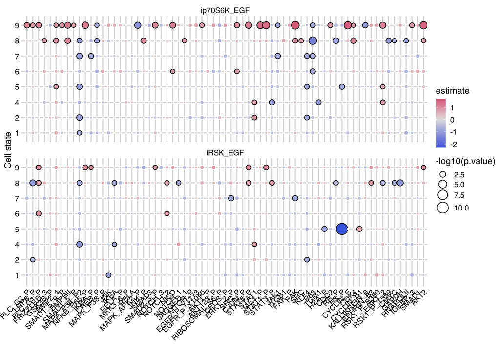

```r
dat_ref3 <- mutate(dat, cluster = forcats::fct_relevel(cluster, "3"))
fit_lst_zscore_ref3 <- purrr::map(ab_name_lst, get_fit, dat_ref3, formula_interaction)

model_ref3 <-
  purrr::map(fit_lst_zscore_ref3, function(x) broom::tidy(x)) %>%
  bind_rows(.id = "ab_name") %>%
  mutate(fdr = p.adjust(p.value, method = "BH")) %>%
  mutate(term_type = case_when(
    str_detect(term, ":") ~ "interaction",
    str_detect(term, "(Intercept)") ~ "intercept",
    str_detect(term, "treatment") ~ "treatment",
    TRUE ~ "cluster"
  ))

signif_interactions_ref3 <-
  model_ref3 %>%
  filter(term_type == "interaction" & p.value < 0.05) %>%
  arrange(fdr) %>%
  separate(term, into = c("cluster", "treatment"), sep = ":", remove = FALSE) %>%
  mutate(
    treatment = stringr::str_replace(treatment, "treatment", ""),
    cluster = stringr::str_replace(cluster, "cluster", "")
  )

plt <-
  model_ref3 %>%
  filter(term_type == "interaction") %>%
  mutate(significant = p.value < 0.05) %>%
  separate(term, into = c("cluster", "treatment"), sep = ":", remove = FALSE) %>%
  mutate(
    treatment = stringr::str_replace(treatment, "treatment", ""),
    cluster = stringr::str_replace(cluster, "cluster", "")
  )  %>%
  mutate(ab_name = factor(ab_name, levels = ordered_ab_lst)) %>%
  # mutate(cluster = factor(cluster, levels = hc_clust$labels[hc_clust$order])) %>%
  ggplot(aes(x = ab_name, y = cluster)) +
  geom_point(aes(size = -log10(p.value), fill = estimate, color = significant), shape = 21) +
  scale_size(range = c(0,5)) +
  scale_color_manual(breaks = c(TRUE, FALSE), values = c("black", "white")) +
  colorspace::scale_fill_continuous_diverging("Blue-Red 2") +
  cowplot::theme_minimal_grid(font_size = 9, font_family = "Helvetica") +
  theme(axis.text.x = element_text(angle = 45, hjust = 1)) +
  labs(x = "", y = "Cell state") +
  guides(color = FALSE) +
  facet_wrap(~treatment, nrow = 2)
plt
```

```r
ggsave(here("figures",  "interaction-terms-ref=C3.pdf"), plt, width = 10, height = 4)
```

How much difference does the reference cluster make? Let’s look at the correlation between estimate effect sizes for the interaction term using Cluster 1 and cluster 3 as reference.

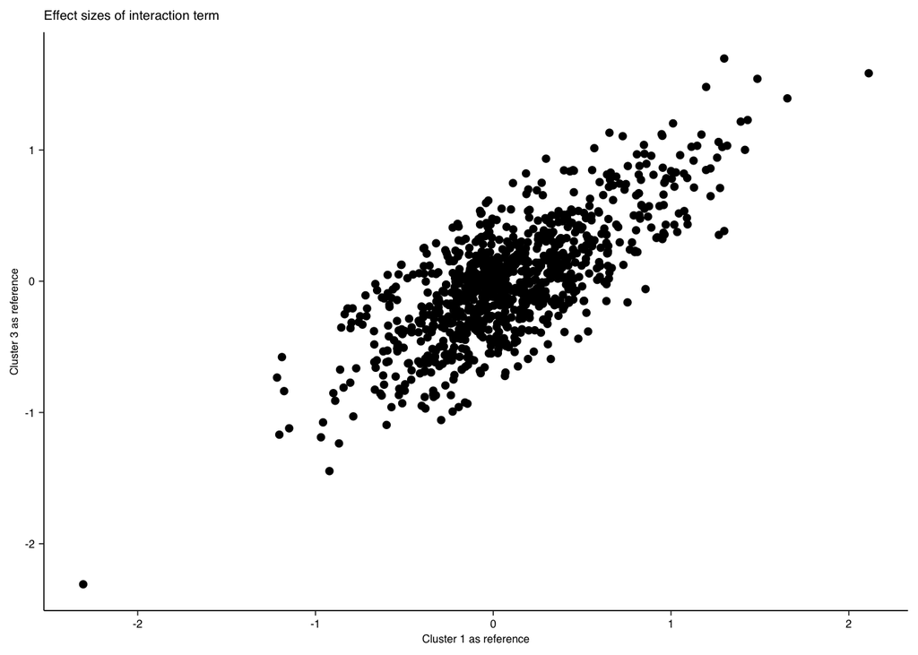

```r
tmp <- filter(model_interaction, term_type == "interaction") %>%
  full_join(
    filter(model_ref3, term_type == "interaction"),
    by = c("ab_name", "term"), suffix = c(".ref1", ".ref3")
    ) %>%
  separate(term, into = c("cluster", "treatement"), sep = ":")


ggplot(tmp, aes(x = estimate.ref1, y=estimate.ref3)) +
  geom_point() +
  my_theme +
  labs(
    x = "Cluster 1 as reference", y = "Cluster 3 as reference",
    title = "Effect sizes of interaction term"
    )
```

The plot above shows that these are highly correlated.

```r
dat_altrefs <- purrr::map(
  c("1", "2", "3", "4", "5", "6", "7", "8", "9"),
  \(x) mutate(dat, cluster = forcats::fct_relevel(cluster, x), ref_cluster = x)
)

fit_lst_altrefs <- purrr::map(
  dat_altrefs,
  \(x) purrr::map(ab_name_lst, get_fit, x, formula_interaction)
)


get_model_altref <- function(fit_lst){
  purrr::map(fit_lst, function(x) broom::tidy(x)) %>%
  bind_rows(.id = "ab_name") %>%
  mutate(fdr = p.adjust(p.value, method = "BH")) %>%
  mutate(term_type = case_when(
    str_detect(term, ":") ~ "interaction",
    str_detect(term, "(Intercept)") ~ "intercept",
    str_detect(term, "treatment") ~ "treatment",
  TRUE ~ "cluster"
  ))
}

model_altref <-
  purrr::map(fit_lst_altrefs, get_model_altref) |>
  bind_rows(.id="id")


model_altref |>
  filter(term_type == "interaction" ) |>
  select(id, term, ab_name, estimate) |>
  pivot_wider(names_from = id, values_from = estimate)
```

```
# A tibble: 1,242 × 11
   term   ab_name     `1`     `2`     `3`     `4`     `5`     `6`     `7`    `8`
   <chr>  <chr>     <dbl>   <dbl>   <dbl>   <dbl>   <dbl>   <dbl>   <dbl>  <dbl>
 1 clust… ITGB1    0.103  NA       0.170   0.352   0.157  -0.149   0.413  -0.548
 2 clust… ITGB1   -0.0679 -0.170  NA       0.182  -0.0139 -0.320   0.243  -0.719
 3 clust… ITGB1   -0.250  -0.352  -0.182  NA      -0.196  -0.502   0.0607 -0.901
 4 clust… ITGB1   -0.0540 -0.157   0.0139  0.196  NA      -0.306   0.256  -0.705
 5 clust… ITGB1    0.252   0.149   0.320   0.502   0.306  NA       0.562  -0.399
 6 clust… ITGB1   -0.310  -0.413  -0.243  -0.0607 -0.256  -0.562  NA      -0.961
 7 clust… ITGB1    0.651   0.548   0.719   0.901   0.705   0.399   0.961  NA
 8 clust… ITGB1   -0.238  -0.341  -0.170   0.0118 -0.184  -0.490   0.0725 -0.889
 9 clust… ITGB1    0.540  NA       0.0595  0.191   0.115   0.0953  0.658  -0.349
10 clust… ITGB1    0.480  -0.0595 NA       0.132   0.0555  0.0358  0.598  -0.409
# ℹ 1,232 more rows
# ℹ 1 more variable: `9` <dbl>
```

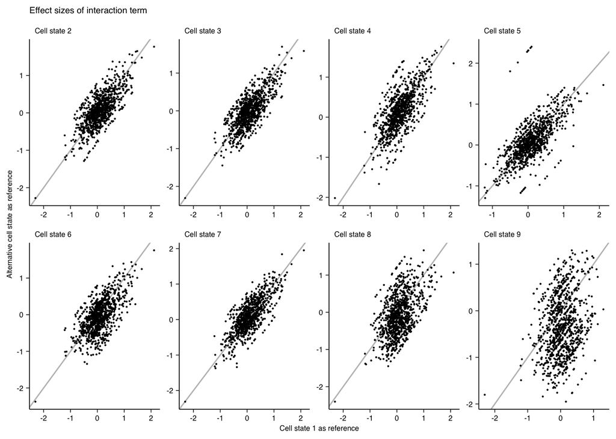

```r
facet_labels_altred <- list(
  '2' = "Cell state 2",
  '3' = "Cell state 3",
  '4' = "Cell state 4",
  '5' = "Cell state 5",
  '6' = "Cell state 6",
  '7' = "Cell state 7",
  '8' = "Cell state 8",
  '9' = "Cell state 9"
)

facet_labeller <- function(variable,value){
  return(facet_labels_altred[value])
}

plt <-
  inner_join(
  model_altref |>
    filter(term_type == "interaction" & id != "1") |>
    select(id, ab_name, term, estimate),
  model_altref |>
    filter(term_type == "interaction" & id == "1") |>
    select(term, ab_name, ref_estimate = estimate),
  by = c("term", "ab_name")
  ) |>
  ggplot(aes(x = ref_estimate, y = estimate)) +
  geom_abline(color = "gray") +
  geom_point(size = 0.1) +
    facet_wrap(~id, labeller = facet_labeller, scales = "free", ncol = 4) +
  my_theme +
  labs(
    x = "Cell state 1 as reference", y = "Alternative cell state as reference",
    title = "Effect sizes of interaction term"
    )

plt
```

```r
ggsave(here("figures","manuscript", "Supplemental figures",  "interaction_term_effectsize_altref.pdf"), plt,
       width = 210, height = 90, units = "mm")
```

## Using altenative inputs

Above we have used the z-score and TMM normalized data to perform the interaction term analysis. Here we just check that using only TMM normalized data (i.e. without subsequent z-score normalization) gives identical p-values for the two-way anova and the regression model.

```r
formula_tmm <- ab_count_tmm ~ cluster * treatment
fit_lst_tmm <- purrr::map(ab_name_lst, get_fit, dat, formula_tmm)

model_tmm <-
  purrr::map(fit_lst_tmm, function(x) broom::tidy(x)) %>%
  bind_rows(.id = "ab_name") %>%
  mutate(fdr = p.adjust(p.value, method = "BH")) %>%
  mutate(term_type = case_when(
    str_detect(term, ":") ~ "interaction",
    str_detect(term, "(Intercept)") ~ "intercept",
    str_detect(term, "treatment") ~ "treatment",
    TRUE ~ "cluster"
  ))

signif_interactions_tmm <-
  model_tmm %>%
  filter(term_type == "interaction" & p.value < 0.05) %>%
  arrange(fdr) %>%
  separate(term, into = c("cluster", "treatment"), sep = ":", remove = FALSE) %>%
  mutate(
    treatment = stringr::str_replace(treatment, "treatment", ""),
    cluster = stringr::str_replace(cluster, "cluster", "")
  )

sum(signif_interactions_tmm$p.value - signif_interactions$p.value > 1e-3)
```

```
[1] 0
```

```r
rm()
```